DS 6030 | Fall 2024 | University of Virginia

# Homework #1: Supervised Learning

Author

**Rohan Shroff**

Published

September 10, 2024

# Required R packages and Directories

```r
library(tidyverse) # functions for data manipulation
```

# Problem 1: Evaluating a Regression Model

## a. Data generating functions

Create a set of functions to generate data from the following distributions:

$$\begin{align*}
X &\sim \mathcal{N}(0, 1) \\
Y &= -1 + .5X + .2X^2 + \epsilon \\
\epsilon &\sim \mathcal{N}(0,\, \sigma)
\end{align*}$$

**Solution**

```r
# generates random x values
sim_x <- function(n) {
  rnorm(n)
}

# defines function y
f <- function(x) {
  -1 + .5*x + .2*(x^2)
}

# generates y values based on x
sim_y <- function(x, sd) {
  n = length(x)
  f(x) + rnorm(n, sd = sd)
}
```

## b. Generate training data

Simulate $n=100$ realizations from these distributions using $\sigma=3$. Produce a scatterplot and draw the true regression line $f(x) = E[Y \mid X=x]$.

- Use `set.seed(611)` prior to generating the data.

**Solution**

```r
n <-  100
sd <-  3

set.seed(611)

x <- sim_x(n)
y <- sim_y(x, sd = sd)

data_train <- tibble(x,y)
```

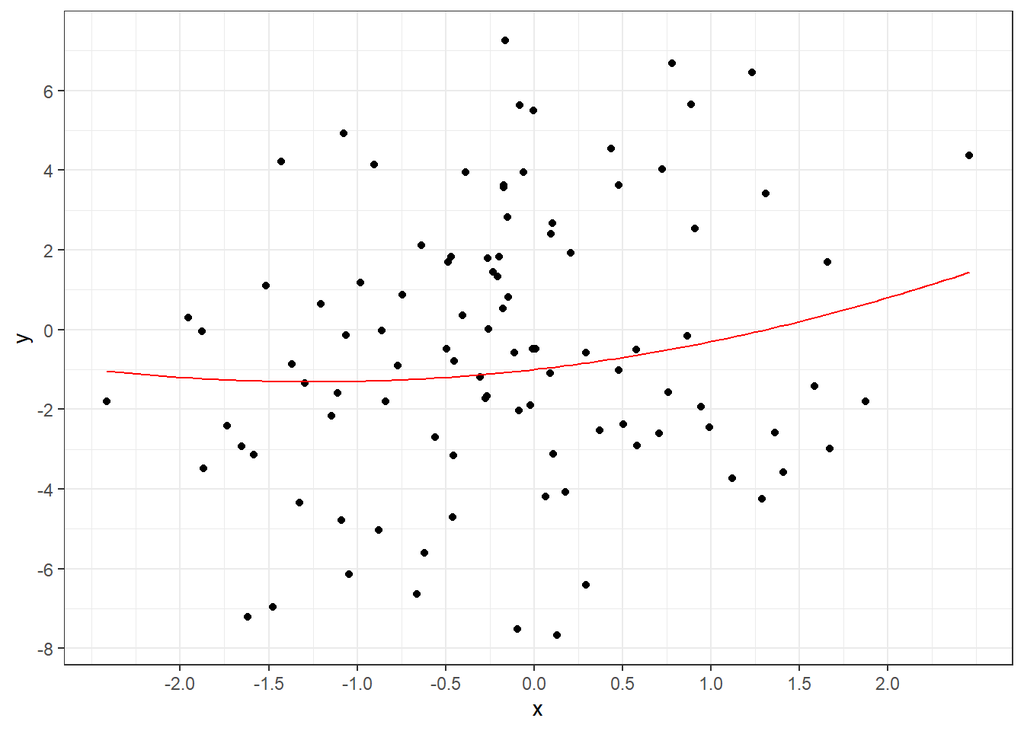

```r
ggplot(data_train, aes(x,y)) + geom_point() +
  geom_function(fun = f, color = 'red') +
  scale_x_continuous(breaks=seq(-2,2, by=0.5)) +
  scale_y_continuous(breaks=seq(-50,50,by=2))
```

## c. Fit three models

Fit three polynomial regression models using least squares: linear, quadratic, and cubic. Produce another scatterplot, add the fitted lines and true population line $f(x)$ using different colors, and add a legend that maps the line color to a model.

- Note: The true model is quadratic, but we are also fitting linear (less complex) and cubic (more complex) models.

**Solution**

```r
# fitting all three models
deg1_model = lm(y~poly(x, degree=1), data=data_train)
deg2_model = lm(y~poly(x, degree=2), data=data_train)
deg3_model = lm(y~poly(x, degree=3), data=data_train)
```

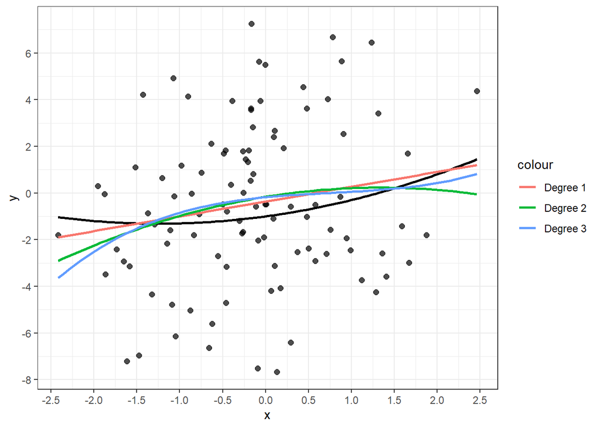

```r
ggplot(data_train, aes(x,y)) + geom_point(size=2, alpha=0.7) +
  geom_function(fun = f, color = 'black', size = 1) +
  stat_smooth(method = "lm", formula = y ~ poly(x, 1), aes(color = "Degree 1"), se = FALSE) + stat_smooth(method = "lm", formula = y ~ poly(x, 2), aes(color = "Degree 2"), se = FALSE) + stat_smooth(method = "lm", formula = y ~ poly(x, 3), aes(color = "Degree 3"), se = FALSE) +
  scale_x_continuous(breaks=seq(-3,3, by=.5)) +
  scale_y_continuous(breaks=seq(-50,50,by=2))
```

## d. Predictive performance

Generate a *test data* set of 10,000 observations from the same distributions. Use `set.seed(612)` prior to generating the test data.

- Calculate the estimated mean squared error (MSE) for each model.
- Are the results as expected?

**Solution**

```r
n_test <- 10000
set.seed(612)

x_test <- sim_x(n_test)
y_test <- sim_y(x_test, sd=sd)
data_test <- tibble(x=x_test, y=y_test)
```

```r
#: Function to fit, predict, and evaluate a polynomial regression model

poly_eval <- function(deg, data_train, data_test){

if(deg==0) m = lm(y~1, data=data_train) # intercept only model

else m = lm(y~poly(x, degree=deg), data=data_train) # polynomial
p = length(coef(m)) # number of parameters
#: calculate training MSE
mse_train = mean(m$residuals^2) # training MSE
#: calculate test MSE
yhat = predict(m, data_test) # predictions at test X's
mse_test = mean( (data_test$y - yhat)^2 )# test MSE
#: output a data frame of relevant info
tibble(degree=deg, edf=p, mse_train, mse_test)
}
```

```r
poly_eval(deg=1, data_train, data_test)
```

```
# A tibble: 1 × 4
  degree   edf mse_train mse_test
   <dbl> <int>     <dbl>    <dbl>
1      1     2      11.3     9.29
```

```r
poly_eval(deg=2, data_train, data_test)
```

```
# A tibble: 1 × 4
  degree   edf mse_train mse_test
   <dbl> <int>     <dbl>    <dbl>
1      2     3      11.2     9.58
```

```r
poly_eval(deg=3, data_train, data_test)
```

```
# A tibble: 1 × 4
  degree   edf mse_train mse_test
   <dbl> <int>     <dbl>    <dbl>
1      3     4      11.2     9.65
```

The results are not as expected. The lowest MSE on the test data occurs when the degree = 1, instead of 2.

## e. Optimal performance

What is the best achievable MSE? That is, what is the MSE if the true $f(x)$ was used to evaluate the test set? How close does the best method come to achieving the optimum?

**Solution**

```r
# function that generates yhat values using true function
gen_yhat <- function(data_test) {

yhat_list <- vector()

for (i in 1:nrow(data_test)){

  yhat <- -1 + .5*data_test$x[i] + .2*(data_test$x[i]^2)

  yhat_list[i] <- yhat
}

yhat_list
}

yhat_list <- gen_yhat(data_test)

# get the test MSE
mse_test <- mean((data_test$y - yhat_list)^2)
```

```r
mse_test
```

```
[1] 8.97
```

This method predictably results in a lower MSE value. The best method out of the 3 models fitted to the data, the linear model, has a test MSE of 9.29. Therefore, a difference in MSE of .32.

## f. Replication

The MSE scores obtained in part *d* came from one realization of training data. Here will we explore how much variation there is in the MSE scores by replicating the simulation many times.

- Re-run parts b. and c. (i.e., generate training data and fit models) 100 times.
  - Do not generate new testing data
  - Use `set.seed(613)` prior to running the simulation and do not set the seed in any other places.
- Calculate the test MSE for all simulations.
  - Use the same test data from part d. (This question is only about the variability that comes from the *training data*).
- Create kernel density or histogram plots of the resulting MSE values for each model.

**Solution**

```r
set.seed(613)

MSE_deg1 <- vector()
MSE_deg2 <- vector()
MSE_deg3 <- vector()

for (i in 1:100){

  n <-  100
  sd <-  3

  x <- sim_x(n)
  y <- sim_y(x, sd = sd)

  data_train <- tibble(x,y)

  deg1_model = lm(y~poly(x, degree=1), data=data_train)
  deg2_model = lm(y~poly(x, degree=2), data=data_train)
  deg3_model = lm(y~poly(x, degree=3), data=data_train)

  # caculate test MSE

  yhat_1 = predict(deg1_model, data_test) # predictions at test X's
  mse_test_deg1 = mean( (data_test$y - yhat_1)^2 )# test MSE

  yhat_2 = predict(deg2_model, data_test) # predictions at test X's
  mse_test_deg2 = mean( (data_test$y - yhat_2)^2 )# test MSE

  yhat_3 = predict(deg3_model, data_test) # predictions at test X's
  mse_test_deg3 = mean( (data_test$y - yhat_3)^2 )# test MSE

  MSE_deg1[i] <- mse_test_deg1
  MSE_deg2[i] <- mse_test_deg2
  MSE_deg3[i] <- mse_test_deg3
}
```

```r
degree <- c(rep(1, length(MSE_deg1)),rep(2, length(MSE_deg2)),rep(3, length(MSE_deg3)))

MSE <- c(MSE_deg1, MSE_deg2, MSE_deg3)
kd_df <- data.frame(degree, MSE)
kd_df$degree <- as.factor(kd_df$degree)
```

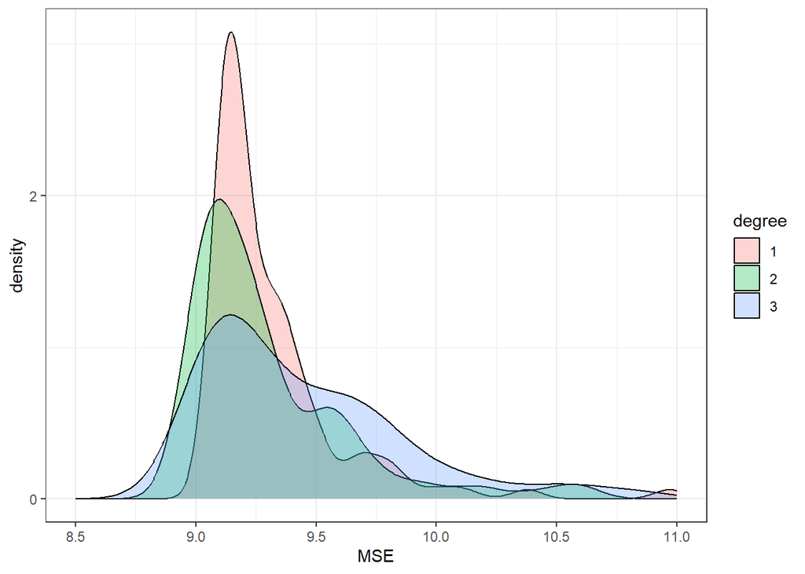

```r
ggplot(kd_df, aes(x=MSE, fill=degree)) +
  geom_density(alpha=0.3) +
  scale_x_continuous(breaks=seq(7,11, by=.5), limits = c(8.5, 11)) +
  scale_y_continuous(breaks=seq(0,50,by=2))
```

## g. Best model

Show a count of how many times each model was the best. That is, out of the 100 simulations, count how many times each model had the lowest MSE.

**Solution**

```r
set.seed(613)

count_best_model1 <- 0
count_best_model2 <- 0
count_best_model3 <- 0

MSE_deg1 <- vector()
MSE_deg2 <- vector()
MSE_deg3 <- vector()

for (i in 1:100){

  n <-  100
  sd <-  3

  x <- sim_x(n)
  y <- sim_y(x, sd = sd)

  data_train <- tibble(x,y)

  deg1_model = lm(y~poly(x, degree=1), data=data_train)
  deg2_model = lm(y~poly(x, degree=2), data=data_train)
  deg3_model = lm(y~poly(x, degree=3), data=data_train)

  # caculate test MSE

  yhat_1 = predict(deg1_model, data_test) # predictions at test X's
  mse_test_deg1 = mean( (data_test$y - yhat_1)^2 )# test MSE

  yhat_2 = predict(deg2_model, data_test) # predictions at test X's
  mse_test_deg2 = mean( (data_test$y - yhat_2)^2 )# test MSE

  yhat_3 = predict(deg3_model, data_test) # predictions at test X's
  mse_test_deg3 = mean( (data_test$y - yhat_3)^2 )# test MSE

  if (mse_test_deg1 < mse_test_deg2 & mse_test_deg1 < mse_test_deg3){
    count_best_model1 <- count_best_model1 + 1
  }

  else if (mse_test_deg2 < mse_test_deg1 & mse_test_deg2 < mse_test_deg3){
    count_best_model2 <- count_best_model2 + 1
  }
  else if (mse_test_deg3 < mse_test_deg1 & mse_test_deg3 < mse_test_deg2){
    count_best_model3 <- count_best_model3 + 1
  }

  MSE_deg1[i] <- mse_test_deg1
  MSE_deg2[i] <- mse_test_deg2
  MSE_deg3[i] <- mse_test_deg3

}
```

```r
model_degree <- c(1, 2, 3)
frequency_best_model <- c(count_best_model1, count_best_model2, count_best_model3)
model_compare_df <- data.frame(model_degree, frequency_best_model)
model_compare_df
```

```
  model_degree frequency_best_model
1            1                   28
2            2                   65
3            3                    7
```

## h. Function to implement simulation

Write a function that implements the simulation in part *f*. The function should have arguments for i) the size of the training data $n$, ii) the standard deviation of the random error $\sigma$, and iii) the test data. Use the same `set.seed(613)`.

**Solution**

```r
f_function <- function(n, sd, data_test) {

  set.seed(613)

  count_best_model1 <- 0
  count_best_model2 <- 0
  count_best_model3 <- 0

  MSE_deg1 <- vector()
  MSE_deg2 <- vector()
  MSE_deg3 <- vector()

  for (i in 1:100){

    n <-  n
    sd <-  sd

    x <- sim_x(n)
    y <- sim_y(x, sd = sd)

    data_train <- tibble(x,y)

    deg1_model = lm(y~poly(x, degree=1), data=data_train)
    deg2_model = lm(y~poly(x, degree=2), data=data_train)
    deg3_model = lm(y~poly(x, degree=3), data=data_train)

    # caculate test MSE

    yhat_1 = predict(deg1_model, data_test) # predictions at test X's
    mse_test_deg1 = mean( (data_test$y - yhat_1)^2 )# test MSE

    yhat_2 = predict(deg2_model, data_test) # predictions at test X's
    mse_test_deg2 = mean( (data_test$y - yhat_2)^2 )# test MSE

    yhat_3 = predict(deg3_model, data_test) # predictions at test X's
    mse_test_deg3 = mean( (data_test$y - yhat_3)^2 )# test MSE

    if (mse_test_deg1 < mse_test_deg2 & mse_test_deg1 < mse_test_deg3){
    count_best_model1 <- count_best_model1 + 1
  }

    else if (mse_test_deg2 < mse_test_deg1 & mse_test_deg2 < mse_test_deg3){
    count_best_model2 <- count_best_model2 + 1
  }
    else if (mse_test_deg3 < mse_test_deg1 & mse_test_deg3 < mse_test_deg2){
    count_best_model3 <- count_best_model3 + 1
  }

    MSE_deg1[i] <- mse_test_deg1
    MSE_deg2[i] <- mse_test_deg2
    MSE_deg3[i] <- mse_test_deg3
  }

  model_degree <- c(1, 2, 3)
  frequency_best_model <- c(count_best_model1, count_best_model2, count_best_model3)
  model_compare_df <- data.frame(model_degree, frequency_best_model)
  model_compare_df
}
```

## i. Performance when $\sigma=2$

Use your function to repeat the simulation in part *f*, but use $\sigma=2$. Report the number of times each model was best (you do not need to produce any plots).

- Be sure to generate new test data with ($n = 10000$, $\sigma = 2$, using `seed = 612`).

```r
set.seed(612)
n_test <- 10000

sd <- 2
x_test <- sim_x(n_test)
y_test <- sim_y(x_test, sd=sd)
data_test_new <- tibble(x=x_test, y=y_test)


f_function(100, 2, data_test_new)
```

```
  model_degree frequency_best_model
1            1                   19
2            2                   71
3            3                   10
```

## j. Performance when $\sigma=4$ and $n=300$

Repeat *i*, but now use $\sigma=4$ and $n=300$.

- Be sure to generate new test data with ($n = 10000$, $\sigma = 4$, using `seed = 612`).

**Solution**

```r
set.seed(612)
n_test <- 10000

sd <- 4
x_test <- sim_x(n_test)
y_test <- sim_y(x_test, sd=sd)
data_test_new1 <- tibble(x=x_test, y=y_test)


f_function(300, 4, data_test_new1)
```

```
  model_degree frequency_best_model
1            1                    8
2            2                   80
3            3                   12
```

## k. Understanding

Describe the effects $\sigma$ and $n$ has on selection of the best model? Why is the *true* model form (i.e., quadratic) not always the *best* model to use when prediction is the goal?

**Solution**

As standard deviation increases, there is more variability in which model is the best. As n increases, there is less variability since there is more data. The true model form (quadratic) is not always the best model to use when prediction is the goal because it might overfit the data.